# Différents tests sur les indices de diversité

## Indice de Shannon

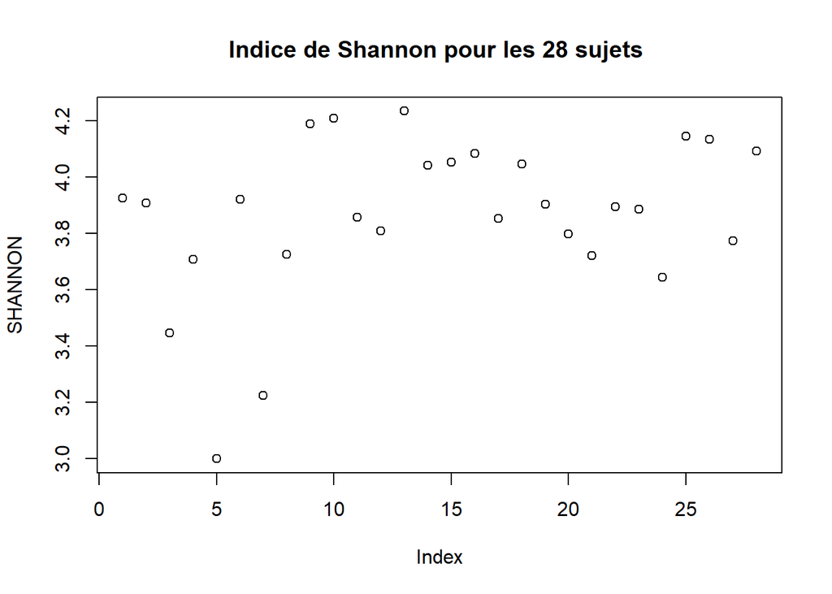

```r
#Shannon
SHANNON<-diversity(matrix_otu, index='shannon')
plot(SHANNON,main="Indice de Shannon pour les 28 sujets ")
```

!! pas une probabilité contrairement à Simpson, souvent entre 1 et 5.

La valeur de l’indice varie de :  
- 0 (une seule espèce, ou bien une espèce dominant très largement toutes les autres)  
- à log(S) (lorsque toutes les espèces ont même abondance).

Est-ce que les sujets avec les indices un peu plus faible sont ceux avec la profondeur de séquençage la plus faible ? On peut regarder la corrélation entre la profondeur de séquençage et l’indice de Shannon:

**Lien avec la profondeur de séquençage**

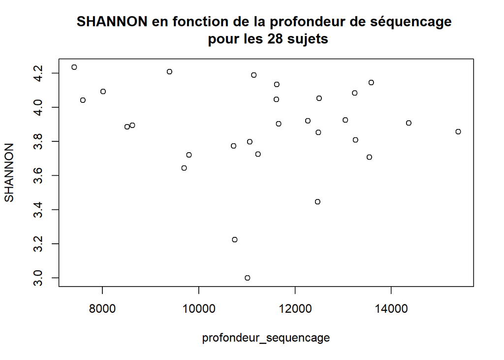

```r
profondeur_sequencage <- apply(matrix_otu, 1, sum)
plot(x=profondeur_sequencage,SHANNON, main="SHANNON en fonction de la profondeur de séquencage \n pour les 28 sujets")
```

```r
summary(lm(SHANNON~profondeur_seq))
```

```
##
## Call:
## lm(formula = SHANNON ~ profondeur_seq)
##
## Residuals:
##      Min       1Q   Median       3Q      Max
## -0.79014 -0.09010  0.02339  0.17755  0.38810
##
## Coefficients:
##                  Estimate Std. Error t value Pr(>|t|)
## (Intercept)     4.295e+00  2.960e-01  14.509  5.6e-14 ***
## profondeur_seq -3.804e-05  2.581e-05  -1.474    0.152
## ---
## Signif. codes:  0 '***' 0.001 '**' 0.01 '*' 0.05 '.' 0.1 ' ' 1
##
## Residual standard error: 0.2785 on 26 degrees of freedom
## Multiple R-squared:  0.07714,    Adjusted R-squared:  0.04164
## F-statistic: 2.173 on 1 and 26 DF,  p-value: 0.1524
```

Il n’existe pas de lien linéaire entre SHANNON et la profondeur de séquencage.

Peut être car de toute façon la profondeur de séquencage est suffisamment élevée dans tous les cas.

**Lien avec la richesse**

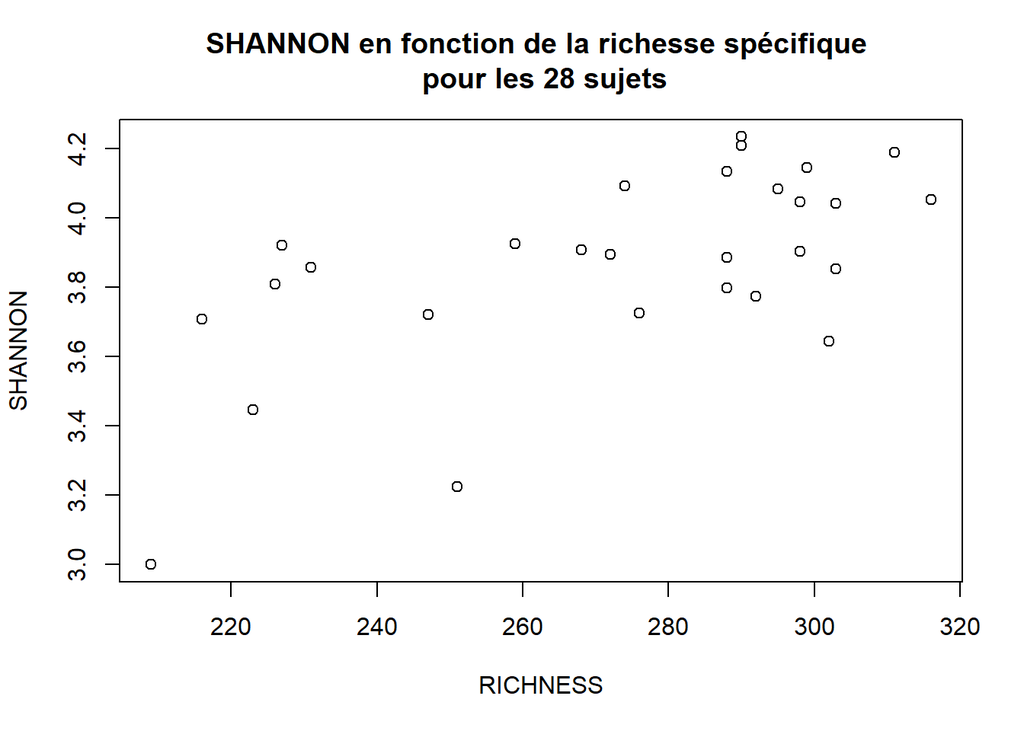

```r
plot(RICHNESS,SHANNON, main="SHANNON en fonction de la richesse spécifique \n pour les 28 sujets")
```

```r
summary(lm(SHANNON~RICHNESS))
```

```
##
## Call:
## lm(formula = SHANNON ~ RICHNESS)
##
## Residuals:
##      Min       1Q   Median       3Q      Max
## -0.51877 -0.14286  0.03814  0.16578  0.31270
##
## Coefficients:
##             Estimate Std. Error t value Pr(>|t|)
## (Intercept)  2.33983    0.37633   6.218 1.41e-06 ***
## RICHNESS     0.00559    0.00137   4.080  0.00038 ***
## ---
## Signif. codes:  0 '***' 0.001 '**' 0.01 '*' 0.05 '.' 0.1 ' ' 1
##
## Residual standard error: 0.2263 on 26 degrees of freedom
## Multiple R-squared:  0.3903, Adjusted R-squared:  0.3668
## F-statistic: 16.64 on 1 and 26 DF,  p-value: 0.0003797
```

Cette fois on a une corrélation positive.

**En faisant varier la taille des séquences**

```r
RARE_CURVE_SHANNON <- function(indiv,filtre_inf = 0,filtre_sup = max(ind)){
      #on choisit un individu
      ind= matrix_otu[indiv,]
      ind= t(ind[which(ind>filtre_inf & ind<=filtre_sup)])

      # On veut passer d'un vecteur de comptage aux données de séquençage d'origine
      # on va donc répéter le nom des OTU autant de fois qu'ils ont été comptés et en faire un vecteur
      sequencage=NULL
      for (i in 1:length(ind)){
        new=rep(rownames(ind)[i], ind[i])
        sequencage=c(sequencage,new)
      }

      # Puis on regarde l'évolution de simpson selon la taille de la séquence
      shannon=NULL
      for (j in seq(1,length(sequencage), by=100)){
        u=sample(as.factor(sequencage), size=j)
        shannon=c(shannon,diversity(table(u), index='shannon'))
      }

      # On crée un data frame pour associer les bonnes profondeurs de séquencages aux valeurs calculées
      rare_curves=data.frame("deep"=seq(1,length(sequencage), by=100),"shannon"=shannon)

      #on retourne le résultat
      return(rare_curves)

}
```

- avec **aucun filtre** :

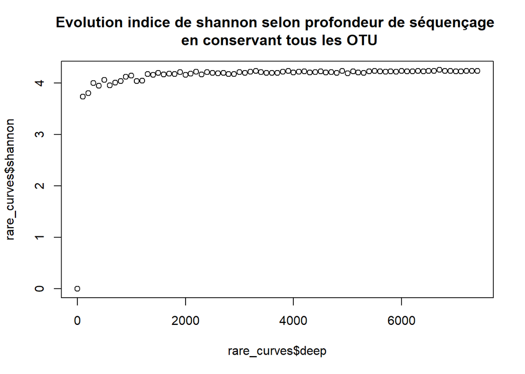

```r
rare_curves <- RARE_CURVE_SHANNON(indiv = "BG-I-D0-CTL")
plot(x=rare_curves$deep,y=rare_curves$shannon , main="Evolution indice de shannon selon profondeur de séquençage \n en conservant tous les OTU" )
```

- en **enlevant les OTU apparus 1 fois** :

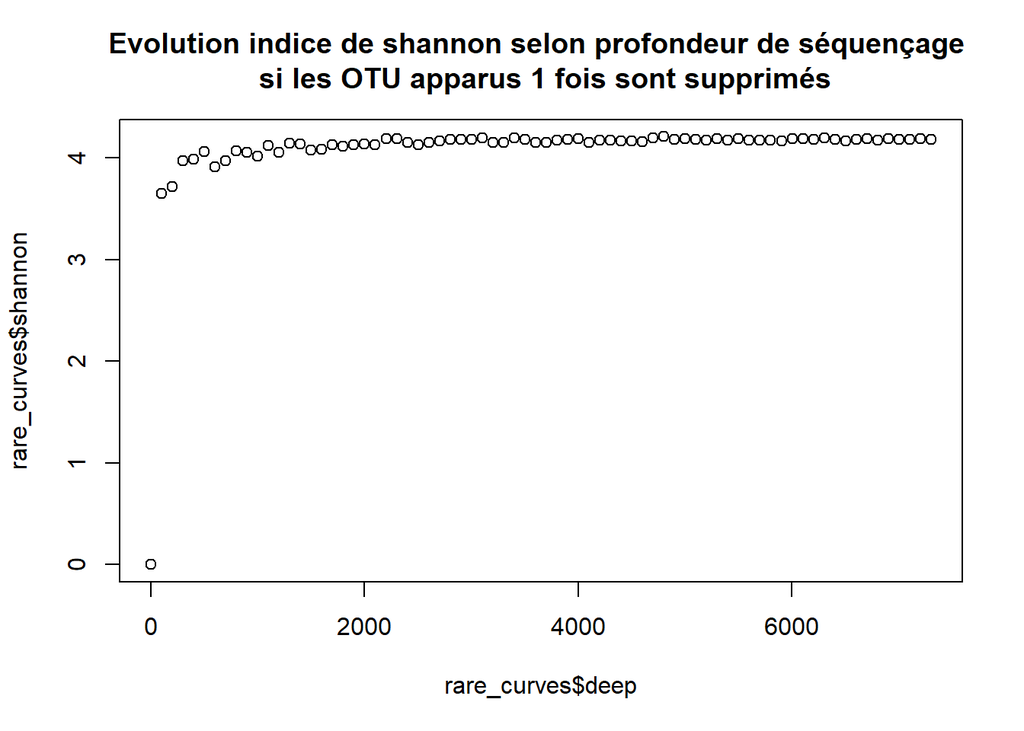

```r
rare_curves <- RARE_CURVE_SHANNON(indiv = "BG-I-D0-CTL",filtre_inf = 1)
plot(x=rare_curves$deep,y=rare_curves$shannon , main="Evolution indice de shannon selon profondeur de séquençage \n si les OTU apparus 1 fois sont supprimés" )
```

- en **enlevant les OTU apparus moins de 5 fois** :

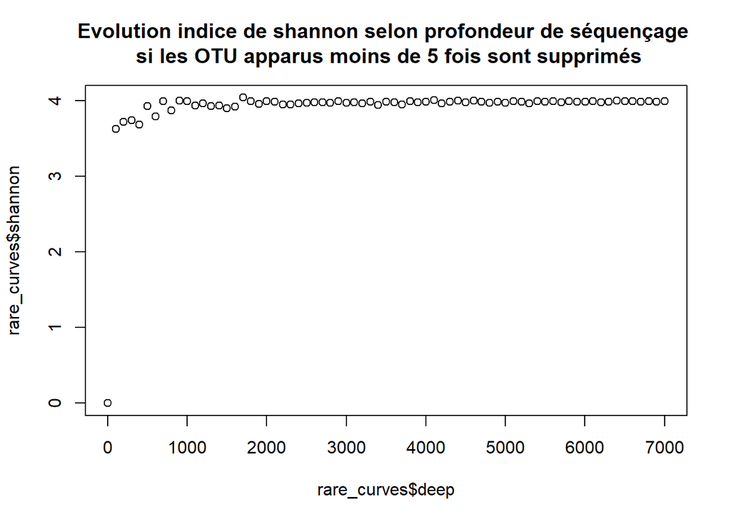

```r
rare_curves <- RARE_CURVE_SHANNON(indiv = "BG-I-D0-CTL",filtre_inf=5)
plot(x=rare_curves$deep,y=rare_curves$shannon , main="Evolution indice de shannon selon profondeur de séquençage \n si les OTU apparus moins de 5 fois sont supprimés" )
```

- en **enlevant les OTU apparus plus de 50 fois** :

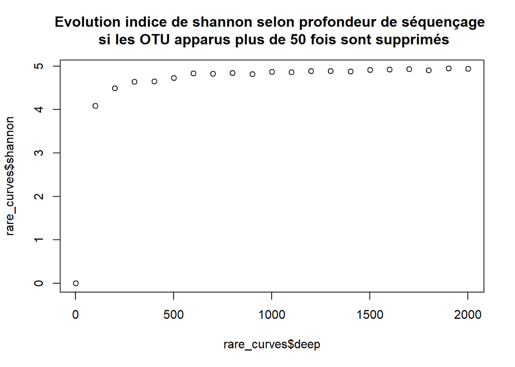

```r
rare_curves <- RARE_CURVE_SHANNON(indiv = "BG-I-D0-CTL",filtre_sup=50)
plot(x=rare_curves$deep,y=rare_curves$shannon , main="Evolution indice de shannon selon profondeur de séquençage \n si les OTU apparus plus de 50 fois sont supprimés" )
```

**RQ**

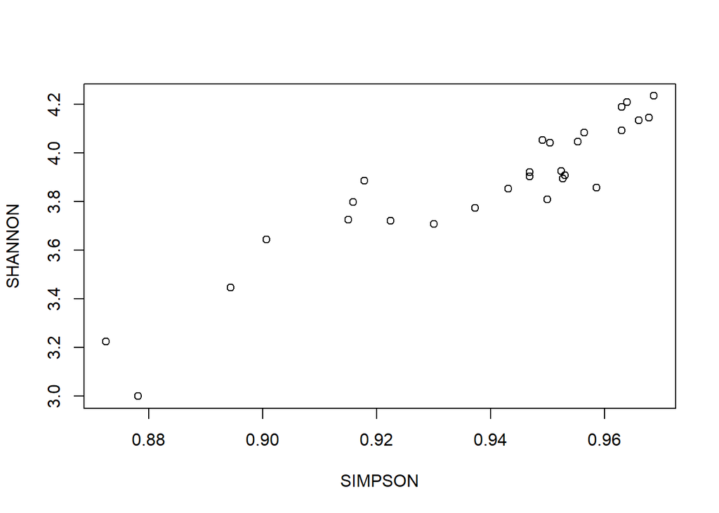

```r
plot(SIMPSON,SHANNON)
```

Les deux indices sont très corrélés, normal qu’on arrive aux mêmes conclusions…

### DIVERSITE ARBRE PHYLOGENETIQUE

https://fr.wikipedia.org/wiki/Diversit%C3%A9_phylog%C3%A9n%C3%A9tique Mesures De très nombreux indices de diversité phylogénétique ont été développés avec les années. Il existe plus de 70 mesures de la diversité phylogénétique, dont plusieurs sont fortement corrélées5. Certains indices ont incorporé l’abondance des différentes unités taxonomiques dans le calcul. Ainsi, pour ces indices, les espèces abondantes ont un poids supérieur ou inférieur comparativement aux espèces rares. D’autres comparent différents ensembles de taxa, un peu comme le fait la diversité bêta. Par exemple, certains indices calculent la longueur des branches des espèces uniques à chaque site. Finalement, certains indices combinent la diversité phylogénétique et le nombre d’espèces. Tous ces indices peuvent être divisés en trois catégories selon ce qu’ils cherchent à mesurer : la richesse, la divergence et la régularité.

Divergence Les mesures de divergence cherchent à quantifier la distribution des taxa d’un ensemble5. Par exemple, il est possible de calculer la divergence phylogénétique en divisant la richesse phylogénétique par la richesse spécifique. Ainsi, on obtient la longueur de branches moyennes reliant chaque unité taxonomique. Une autre mesure courante de la divergence est de calculer la moyenne des longueurs de branches entre chaque paire de taxa. Ainsi, on mesure la distance phylogénétique moyenne entre les taxa. Ces indices servent donc à quantifier la différence entre les unités taxonomiques d’un ensemble d’intérêt.

Régularité La régularité mesure à quel point les taxa d’un ensemble sont également distancés phylogénétiquement5. En d’autres mots, on compare la distribution des taxa d’une phylogénie à un arbre phylogénétique dont tous les taxa ont une distance évolutive égale. La régularité est maximale lorsque toutes les paires d’espèces sont également distancées sur l’arbre phylogénétique. Au contraire, si certaines espèces sont très proches et d’autres éloignées, la régularité sera inférieure. Une mesure permettant de quantifier cette régularité phylogénétique est la variance des distances entre chaque paire d’un ensemble.